# Simulation Methods for the Assessment and MSE for Short-Lived Species

## 5.5 Conditioning Reference Set Operating Models

The purpose of MSE is to simulation test candidate management procedures (MPs - a rule for calculating management advice from data) and potentially select an MP that can meet management objectives robustly.

The typical approach for this simulation testing is to establish operating models of system dynamics that are credible empirically. This usually involves conditioning operating models on data. In some cases, operating model conditioning is done with custom models such as JJM (Jim Ianelli’s custom Pacific Jack Mackerel assessment model) or (M3, the multi-stock, seasonal, spatial model for Atlantic Bluefin Tuna MSE). However, in other cases conventional stock assessmments such as Stock Synthesis 3 are used to fit operating models, as was the case for the North Atlantic Swordfish MSE and the Western Skipjack Tuna MSE.

The OpenMSE package has a number of tools for converting such assessments to operating models such as SS2OM (Stock Synthesis) and the more generic Assess2OM (input is a list of age-based arrays by simulation and year).

OpenMSE also includes RCM. Although it was tested in a kind of ‘assessment model’ above, RCM was expressly designed to condition operating models. It follows that an approach to conditioning operating models for a short-lived stock would be to simulate a very wide range of possible stock and fishery dynamics (as above), configure an RCM model that can suitably estimate key aspects of stock and fishery dynamics and then use RCM.

It turns out this is straightforward because after estimation, RCM returns an complete OpenMSE operating model that can be used for projections.

Normally we would be submitting real fishery data to the RCM. In lieu of those data, for the purposes of this demo RCM will be fitted to simulation 1 of the simulated data above:

```r
OM = RCM_data(1, simdata, "Fit to sim data in lieu of real data",
              M = 0.5,                # Quarterly natural mortality rate
              R0init = 1E7,           # Initial value for unfished recruitment
              Steepness = 0.7,        # Assumed steepness of Ricker SRR
              i_oe  = 0.1,            # 10% CV on abundance indices
              ESS = 25,               # Effective Sample Size of 25 pa for Lcomp
              nSim = 16)              # Make OM 16 simulations big
```

```
## Weight at age not specified, taking a bad guess from simulations (averaged over stocks and simulations)
## Length at age not specified, taking a bad guess from simulations (averaged over stocks and simulations)
## Maturity at age not specified, taking a bad guess from simulations (averaged over stocks and simulations)
## Selectivity at age not specified, taking a bad guess from simulations (averaged over stocks and simulations)
```

```r
fit = RCM(OM,                         # OM is an operating model
          OM@cpars$Data,              # That has the real data appended
          s_selectivity=c("B",1,2),   # Biomass survey, fleet 1 and 2 CPUE
          max_F = 3.0, mean_fit = T,  # report on a single fit to mean params
          condition = "catch",        # remove catch exactly
          cores = 8,                  # run in parallel
          resample = T,               # resample nsim from the var-covar matrix
          drop_nonconv = T)           # drop any non converged fits

myOM = Seasonality(fit@OM, Seasons = 4) # Add seasonality in dynamics
```

```
##   spec q   spec mu model q simulated mu
## 1      1 1.1184310       1    1.4258495
## 2      2 1.8959362       2    2.8207319
## 3      3 1.9483549       3    3.3571159
## 4      4 0.7829494       4    0.3785486
```

```r
hist = Simulate(myOM)                 # Historical reconstruction
```

Now that we have a conditioned seasonal operating model we can test management procedures.

OpenMSE comes with a few examples:

```r
avail('mp')
```

```
## → Searching for objects of class "mp" in package "MSEtool"
```

```
## → Searching for objects of class "mp" in package "SAMtool"
```

```
## → Searching for objects of class "mp" in package "DLMtool"
```

```
## [1] "AverageCatch"    "CurrentCatch"    "CurrentEffort"   "CurrentLandings"
```

These are pretty basic but the OpenMSE selection will grow with future releases (please make requests on the MSEtool GitHub Issues page!)

The slMSE packages comes with a Generic Index Ratio (GIR) management procedure of the type used to provide advice in stocks such as Atlantic Bluefin Tuna and North Atlantic Swordfish.

Essentially the MP aims to adjust TACs based on an index of abundance. The MP is calibrated such that TAC advice is relative to catches in the last historical year (e.g. 120 tons in 2026) and future index levels in the last historical year (e.g. 36.1821 in 2026). The MP is names ‘generic’ because we are not supplying an observed historical index of abundance but rather using the internally generated relative biomass index. It is trivial to add real data and simulate the statistical properties of a real index, we just don’t have these!

To find out more about GIR you can use the in-line help:

```r
?GIR
```

```
## starting httpd help server ... done
```

The GIR has a number of features. It can smooth indices with a polynomial to remove noise from signal, it can limite upward and downward changes in TAC and can use control points that impact how advice will be generated.

We can actually plot a GIR configuration by modifying the function (to plot) and using an example dataset that was loaded with slMSE:

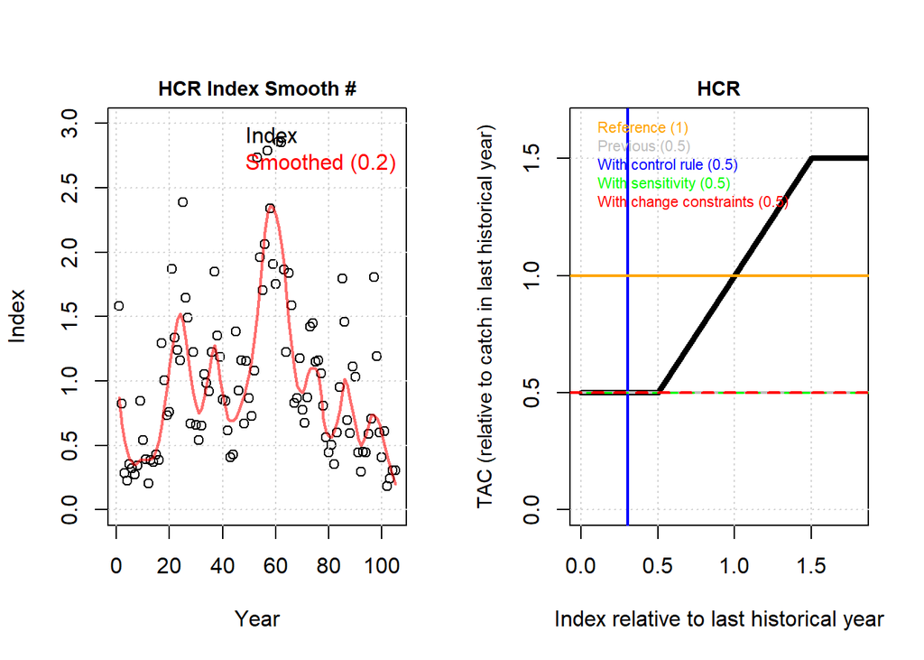

```
## ── A  `?MSEtool::advice-class()` Object ──
```

```
## `TAC`: 162040.7909
```

```
## `TACType`: "Removals"
```

```
## `TACUnit`: "Biomass"
```

```
## `Effort`: not specified
```

```
## `EffType`: "Rel"
```

```
## `Closure`: not specified
```

```
## `Selectivity`: not specified
```

```
## `Retention`: not specified
```

```
## `DiscardMortality`: not specified
```

```
## `ApicalF`: not specified
```

```r
plotGIR = GIR   # copy function
formals(plotGIR)$plot = T

par(mfrow=c(1,2))
plotGIR(Example_Data)
```

Lets run the default GIR MP along with a version ‘myGIR’ that we have modified:

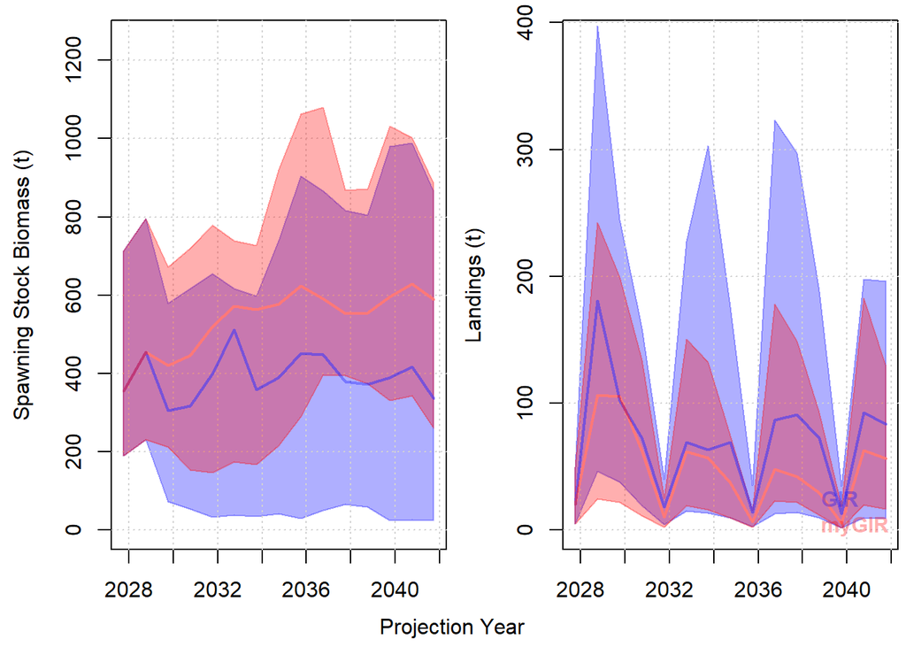

```r
myGIR= GIR                                # Copy Generic Index Ratio MP
formals(myGIR)$HCR_ICP = c(0.5, 2)        # Below 50% historical index there is
formals(myGIR)$HCR_LCP = c(0, 0.8)        #     zero catch, max catch 80% hist
formals(myGIR)$HCR_up_max = 0.5           # Maximum upward adjustment of 50%
formals(myGIR)$HCR_down_max = 0.5         # Maximum downward adjustment of 50%
class(myGIR) = 'mp'                       # Assign correct class

anMSE = Project(hist, c("GIR","myGIR"))   # Closed-loop projections
slplot(anMSE)                             # MSE results
```

## 5.6 Specifying Robustness Operating Models

Coming soon!

## 5.7 Specifying Alternative Projection dynamics

Coming soon!

## 5.8 Developing In-Season Management Procedures

Coming soon!

## 5.9 Including Environmental Drivers of Stock Productivity

Coming soon!

## 5.10 Quantifying Appropriate Fishery Management Reference Points

Coming soon!

# 6 Examples

## 6.1 Neon Flying Squid

TBD

## 6.2 Jumbo Flying Squid

TBD

## 6.3 Deep Water Red Shrimp

TBD

# 7 References

Alexander I Arkhipkin, Lisa C Hendrickson, Ignacio Payá, Graham J Pierce, Ruben H Roa-Ureta, Jean-Paul Robin, Andreas Winter, Stock assessment and management of cephalopods: advances and challenges for short-lived fishery resources, ICES Journal of Marine Science, Volume 78, Issue 2, March 2021, Pages 714–730, https://doi.org/10.1093/icesjms/fsaa038

NPFC, 2025. NPFC-2025-SSC NFS02-WP02. Overview of Stock Assessment Methods and Management Measures Used for Squids and Other Short-Lived Species. https://www.npfc.int/system/files/2025-06/NPFC-2025-SSC%20NFS02-WP02%20Overview%20SA%20Methods%20and%20Management%20Measures.docx

NPFC, 2025. NPFC-2025-SSC NFS02-IP06Management Strategy Evaluation for Short-Lived Species with Only Annual Data: A Case Study of the Autumn Cohort of Neon Flying Squid in the North Pacific Ocean, https://www.npfc.int/system/files/2025-07/NPFC-2025-SSC%20NFS02-IP06%20Data%20moderate%20MSE%20for%20short-lived%20species.pdf

# 8 Acknowledgements

Funding support for this project was provided by:

The Pew Charitable Trusts

The views expressed herein are those of the authors and do not necessarily reflect the views of The Pew Charitable Trusts.

Contact point for Pew Charitable Trusts - Ashley Wilson, Science Officer, International Fisheries (awilson@pewtrusts.org).

# 9 Appendix: Operating Models

An operating model is a theoretical description of fishery and population dynamics used for the testing of management strategies that could include, for example, data collection protocols, stock assessment methods, harvest control rules, enforcement policies and reference points. In fisheries, operating models are used in closed-loop simulation to test management procedures (aka. harvest strategy) accounting for feedback among the system, data, management procedure and implementation. A management procedure is a rule that calculates management advice from data. Management Strategy Evaluation uses closed-loop simulation of management procedures as a core technical component but is a wider process of stakeholder and manager engagement that identifies system uncertainties, performance metrics, viable management procedures, ultimately aiming to adopt an MP for the provision of management advice for an established time period.

## 9.1 Reference Case Operating Models

The reference case operating model is used as the single ‘base’ operating model from which reference set and robustness set operating models are specified. Reference and robustness tests are typically 1-factor departures from the reference case OM, however sometimes reference set OMs are organized in a factorial grid across primary axes of uncertainty.

## 9.2 Reference Set Operating Models

Reference set operating models span a plausible range of the core uncertainties for states of nature. These are often the types of alternative parameterizations or assumptions that would be included in a stock assessment sensitivity analysis.

The role of the reference set operating models is to provide the central basis for evaluating the performance of candidate management procedures, for example rejecting badly performing harvest strategies.

## 9.3 Robustness Set Operating Models

Robustness set operating models are intended to include additional sources of uncertainty for providing further discrimination among management procedures that perform comparably among reference set operating models.

Robustness operating models often represent system states of nature that are not empirically informed or are hypotheses of a subset of stakeholders.

***